# 08-Datos faltantes

Teresa Ortiz

El problema de datos faltantes surge en casi todo análisis estadístico.

### Datos faltantes en redes bayesianas

Recordemos que dada una estructura gráfica dirigida ${\mathcal G}$, consideramos modelos de la forma

$p(x,\theta)=\prod_{j=1}^k p(x_j|Pa(x_j),\theta)$

donde $\theta$ contiene todos los parámetros de los modelos locales. Dada una muestra $\mathcal L$, podemos estimar $\theta$ maximizando la verosimilitud $L(\theta;{\mathcal L})=\prod_{i=1}^n p(x^{(i)}, \theta).$ Recordamos también que en este problema los parámetros de cada modelo local se separan en factores distintos, de forma que la verosimilitud se descompone según la factorización de la primera ecuación.

Ahora queremos entender qué hacer cuando hay datos faltantes en la muestra $\mathcal L$.

**Ejemplo.** Escogemos al azar una moneda y luego tiramos un volado con esa moneda:

```r
ej_1 <- data.frame(moneda = c('A', 'A', 'B', 'B', 'B', NA),
  sol = c(1, 0, 0, 0, 1, 0))
ej_1
```

```
##   moneda sol
## 1      A   1
## 2      A   0
## 3      B   0
## 4      B   0
## 5      B   1
## 6   <NA>   0
```

Suponemos que no sabemos la moneda que se usó para el último volado. ¿Cómo procederíamos para hacer la estimación de los parámetros de este modelo (son 3)?

En general, las últimas dos estrategias son las únicas que tienen sentido. En esta parte, nos concentraremos en la segunda: ¿cómo hacemos máxima verosimilitud con datos faltantes?

**Ejemplo**. En nuestro ejemplo no podemos simplemente ignorar los datos. Supongamos el modelo moneda -> sol. Eliminando la observación última, máxima verosimilitud equivale a hacer conteos, y obtendríamos

```r
prop.table(table(ej_1$moneda))
```

```
##
##   A   B
## 0.4 0.6
```

```r
prop.table(table(ej_1$moneda, ej_1$sol), 1)
```

```
##
##        0    1
##   A 0.50 0.50
##   B 0.67 0.33
```

Si parametrizamos con $\theta=P(moneda=A)$, $\theta_A=P(sol|moneda=A)$ y $\theta_B=P(sol|moneda=B)$, estos tres parámetros on

```r
prop.table(table(ej_1$moneda))[1]
```

```
##   A
## 0.4
```

```r
prop.table(table(ej_1$moneda, ej_1$sol), 1)[, 2]
```

```
##    A    B
## 0.50 0.33
```

Sin embargo, la estimación cambia considerablemente si consideramos las dos posibilidades para moneda:

```r
ej_temp <- ej_1
ej_temp[6, 'moneda'] <- 'A'
prop.table(table(ej_temp$moneda))
```

```
##
##   A   B
## 0.5 0.5
```

```r
prop.table(table(ej_temp$moneda, ej_temp$sol), 1)
```

```
##
##        0    1
##   A 0.67 0.33
##   B 0.67 0.33
```

```r
ej_temp <- ej_1
ej_temp[6, 'moneda'] <- 'B'
prop.table(table(ej_temp$moneda))
```

```
##
##    A    B
## 0.33 0.67
```

```r
prop.table(table(ej_temp$moneda, ej_temp$sol), 1)
```

```
##
##        0    1
##   A 0.50 0.50
##   B 0.75 0.25
```

No está claro entonces que sea buena idea eliminar el caso faltante. ¿Cómo adaptamos la verosimilitud para lidiar con este caso?

En primer lugar, obsérvese que la parte que corresponde a la log verosimilitud para los datos completos (caso 1 a 5) es $\log (\theta\theta_A) + \log(\theta(1-\theta_A)) + 2\log((1-\theta)(1-\theta_B))+ \log((1-\theta)\theta_B)$ Que es igual a $2\log\theta+3\log(1-\theta)+\log\theta_A+\log(1-\theta_A)+2\log(1-\theta_B)+\log\theta_B$

Verificamos nuestro resultado anterior optimizando directamente (escogimos una parametrización no tan buena. Es mejor usar logits):

```r
logLik<- function(theta){
  2 * log(theta[1]) + 3 * log(1 - theta[1]) + log(theta[2]) + log(1 - theta[2]) +
    log(theta[3]) + 2 * log(1 - theta[3])
}
optim_1 <- optim(c(0.1, 0.1, 0.5), logLik, control=list(fnscale = -1))
optim_1$convergence
```

```
## [1] 0
```

```r
optim_1$par
```

```
## [1] 0.40 0.50 0.33
```

Y notamos que, en efecto, son iguales a los que habíamos calculado directamente con conteos.

Ahora incluiremos a la log verosimilitud un término adicional de la contribución del último caso.

¿Qué sabemos del último caso? Sabemos que $x^{6}_{sol}=0$, y el valor de $x^{6}_{moneda}$ fue censurado. Consideramos entonces el término (que es una variable aleatoria): $p_{\theta}(x^{6}_{sol}=0 , r^{6}_{moneda}=1, x^6_{moneda}),$ donde $r^{6}_{moneda}$ es una variable indicadora de casos faltante.

El primer punto importante es que hay que *hacer algún supuesto probabilístico acerca del mecanismo de censura para poder resolver nuestro problema por máxima verosimilitud*.

Para calcular esta cantidad, reescribimos como

$p_{\theta}(x^{6}_{sol}=0, x^6_{moneda})p(r^{6}_{moneda}=1|x^{6}_{sol}=0, x^6_{moneda})$ Con el modelo podemos marginalizar el primer término, pero no podemos marginalizar porque tiene el segundo término.

Podríamos simplificar suponiendo que el segundo término no depende de $\theta$, y adicionalmente, que $p(r^{6}_{moneda}=1|x^{6}_{sol}=0, x^6_{moneda})=p(r^{6}_{moneda}=1|x^{6}_{sol}=0).$ Es decir, el valor censurado de la moneda no cambia la probabilidad de censura. Esto ayuda porque entonces porque podemos marginalizar el producto con el modelo, obteniendo

$K\sum_x p_{\theta}(x^{6}_{sol}=0, x^6_{moneda}=x)$

donde $K$ es una constante que no depende de $\theta$, y podemos ignorar para hacer máxima verosimilitud.

Para usar nuestra parametrización local escribimos entonces: $p_{\theta}(x^{6}_{sol}=0 )=p_{\theta}(x^{6}_{sol}=0 |x^{6}_{moneda}=A) p_{\theta}(x^{6}_{moneda}=A) + p_{\theta}(x^{6}_{sol}=0 |x^{6}_{moneda}=B) p_{\theta}(x^{6}_{moneda}=B),$ que en términos de $\theta$ se escribe como $(1-\theta_A)\theta + (1-\theta_B)(1-\theta)$ y ahora podemos entonces maximizar $2\log\theta+3\log(1-\theta)+\log\theta_A+\log(1-\theta_A)+2\log(1-\theta_B)+\log\theta_B + \log((1-\theta_A)\theta + (1-\theta_B)(1-\theta)).$

Nótese que este problema es más difícil que el de datos completos, pues la verosimilitud ya no es separable en modelos locales. Podemos resolver numéricamente:

```r
logLikFaltantes <- function(theta){
  logLik(theta) + log((1 - theta[2]) * theta[1] + (1 - theta[3]) * (1 - theta[1]))
}
optim_2 <- optim(c(0.1, 0.1, 0.5), logLikFaltantes, control = list(fnscale = -1))
optim_2$convergence
```

```
## [1] 0
```

```r
optim_2$par
```

```
## [1] 0.39 0.43 0.27
```

Nótese en primer lugar que las condicionales de sol bajaron: esto es porque observamos un 0 adicional en la variable *sol*. Bajan las dos pues no sabemos qué moneda se utilizó. En segundo lugar, bajó un poco la probabilidad de moneda A, y esto es porque los ceros están más fuertemente asociados con la moneda B, de forma que es más probable que la moneda utilizada haya sido la B, pues observamos una águila en el caso faltante.

Si calculamos la marginal de águilas y soles vemos otra verificación de que estamos usando todos los datos:

```r
optim_2$par[2]*optim_2$par[1]+optim_2$par[3]*(1-optim_2$par[1])
```

```
## [1] 0.33
```

y esto es pues en la columna de soles hay 1/3 de soles. Por otra parte:

```r
optim_1$par[2]*optim_1$par[1]+optim_1$par[3]*(1-optim_1$par[1])
```

```
## [1] 0.4
```

Para aplicar máxima verosimilitud en presencia de datos faltantes, necesitamos:

- Además del modelo de los datos, necesitamos un modelo probabilístico para la aparición de faltantes en los datos.
- Supuestos acerca del modelo de datos faltantes que simplifique el análisis.
- Resolver el problema de máxima verosimilitud con datos faltantes, que típicamente es más difícil que el problema correspondiente a datos completos.

Abajo introducimos algunas ideas y notación para generalizar los primeros dos puntos. La idea principal es modelar el proceso que censura datos de manera probabilística, hacer supuestos razonables para este proceso, e incluirlo en nuestro proceso de estimación.

En primer lugar, el modelo para los datos completos está parametrizado con $\theta$: $p_{\theta}(y)$

El proceso de censura lo incluimos de la siguiente forma: tenemos un vector $I$ de indicadores de faltantes ($I_{j}=1$ cuando el dato $j$ está censurado faltante), y el modelo para el mecanismo de faltantes está parametrizado con $\psi$ y está dado por: $p_{\psi} (I|y)$

Entonces generamos los datos según $p_{\theta}(y)$ y luego censuramos observaciones según $p_{\psi} (I|y)$. Los datos que obtenemos son los valores no censurados, junto con la indicadora de qué valores fueron censurados. Así, el modelo completo para nuestras observaciones es: $p_{\theta,\psi} (y,I)=p_{\theta}(y)p_{\psi}(I|y).$

Finalmente, escribiremos $y=(y_{obs},y_{falta})$ para denotar por separado datos observados y datos faltantes.

Generamos ahora algunas observaciones de este modelo (que suponemos iid).

```r
set.seed(280572)
N <- 1000
moneda <- sample(c('A', 'B'), N, replace = T)
sol <- rbinom(N, 1, ifelse(moneda=='A', 0.5, 0.33))
datos_L <- data.frame(moneda, sol)
head(datos_L, 30)
```

```
##    moneda sol
## 1       A   0
## 2       B   0
## 3       A   1
## 4       B   0
## 5       A   1
## 6       B   0
## 7       A   0
## 8       A   1
## 9       B   1
## 10      A   1
## 11      B   0
## 12      B   1
## 13      A   1
## 14      B   0
```

[output cut: 16 more lines]

y ahora censuramos según el modelo de censura:

```r
censura_moneda <- rbinom(N,1, ifelse(sol == 1, 0.3, 0))
censura_sol <- rbinom(N, 1, 0.2)
```

Y obtenemos las observaciones:

```r
datos_L_obs <- datos_L
datos_L_obs[censura_moneda == 1, 'moneda'] <- NA
datos_L_obs[censura_sol == 1, 'sol'] <- NA
head(datos_L_obs, 30)
```

```
##    moneda sol
## 1       A   0
## 2       B   0
## 3       A   1
## 4       B   0
## 5       A   1
## 6       B   0
## 7       A  NA
## 8       A  NA
## 9       B  NA
## 10   <NA>   1
## 11      B  NA
## 12      B   1
## 13      A   1
## 14      B   0
```

[output cut: 16 more lines]

La verosimilitud para nuestros datos observados está dada por $p(y_{obs},I),$ pues sabemos los valores de las variables observadas y qué datos faltan. Para hacer máxima verosimilitud tenemos entonces que encontrar esta conjunta. Esto lo hacemos promediando (marginalizando) sobre $y_{falta}$ (que consideramos como variables aleatorias) :

$p_{\theta,\phi} (y_{obs},I)=\int p_{\phi}(I|y_{obs},y_{falta})p_{\theta} (y_{obs}, y_{falta})d y_{falta}.$

Nótese que esta integral (o suma, dependiendo del caso), promedia los valores faltantes según el modelo de los datos $p_{\theta}$

De la ecuación de arriba, vemos que en general tendríamos que modelar también el mecanismo de datos faltantes y estimar todos los parámetros. Esto es difícil no solamente porque hay más parámetros, sino porque en la práctica *puede ser difícil proponer un modelo razonable para datos faltantes*. En este punto, preferimos hacer un supuesto (que puede cumplirse o no para cada problema particular), y obtener una solución.

- Decimos que el mecanismo de censura es **MCAR (missing completely at random, o faltante totalmente al azar)** cuando se cumple $p_{\phi}(I|y_{obs},y_{falta})=p_{\phi}(I).$ Esto es, una variable es MCAR si la probabilidad de faltar es la misma para todas las unidades. Por ejemplo, si todos los encuestados deciden si contestar la pregunta de *ingresos* lanzando un dado y negansdose a contestar si observa un 6. En el caso MCAR eliminar las observaciones con faltantes no genera un sesgo en la inferencia.
- Decimos que el mecanismo de censura es **MAR (missing at random o faltante al azar)** cuando $p_{\phi}(I|y_{obs},y_{falta})=p_{\phi}(I|y_{obs}),$ es decir, la probabilidad de censura de una una variable dada no depende de los valores que toma esa variable, pero puede depender de otros datos observados. En la mayor parte de los casos los faltantes no cumplen MCAR. Por ejemplo, la tasa de no respuesta suele diferir entre blancos y negros, esto es un indicador de que la pregunta *ingresos* no cumple los supuestos de MCAR.  
  El supuesto de MAR es más general, por ejemplo si observamos *genero*, *raza*, *educación* y *edad* para todos los encuestados, enotnces *ingresos* es MAR si la porbabilidad de no-respuesta para esta pregunta depende únicamente de estas variables completamente observada.
- En otro caso, decimos que el mecanismo de censura es **MNAR (missing not at random).** Notemos que faltantes dejan de ser aleatorios cuando dependen de información que no se colectó. Por ejemplo, es común que en ensayos clínicos si un tratamiento particular causa molestias los pacinetes son más propensos a abandonar el estudio, y dado que se busca medir la eficacia de cada tratamiento tenemos faltantes no aleatorios. Otro caso de falatantes no aleatorios es cuando la probabilidad de que cierta variable falte depende de la variable misma. Por ejemplo, supongamos que la gente con mayor ingreso es menos propensa a revelarlo. El caso extremo (por ejemplo, todas las personas con ganancia mayor a $100,000 se rehusan a contestar) se conoce como censura. Cuando tenemos MNAR es necesario modelar el mecanismo de datos faltantes, o aceptar que nuestros resultados serán sesgados.

**Ejemplo.** En nuestro ejemplo de las monedas, los faltantes de soles son MCAR, mientras que los faltantes de monedas son sólo MAR, pues la probabilidad de censura cambia con el valor del volado. Los procesos de censura de cada variable son independientes, así que estos datos son MAR.

Más adelante discutimos estos supuestos. Nótese que si se cumple MAR, entonces tenemos que $p_{\theta,\psi} (y_{obs},I)= p_{\psi}(I|y_{obs})\int p_{\theta} (y_{obs}, y_{falta})dy_{falta}.$

Lo interesante de esta expresión es que los parámetros $\psi$ y $\theta$ están en factores separados. Esto implica que para maximizar el lado izquierdo, hay que maximizar por separado los dos factores. Más interesante es que para encontrar los estimadores de máxima verosimilitud, **no es necesario trabajar con $\psi$ ni el mecanismo al azar. Esto es, el mecanismo de faltantes es ignorable.** En otras palabras,

Si el mecanismo de censura es MAR, podemos maximizar verosimilitud simplemente maximizando la verosimilitud completa donde los valores censurados están integrados respecto a la condicional de modelo de los datos. **El cumplimiento de MAR depende del fenómeno que produce los datos y del modelo que estamos usando**.

**Ejemplo**. Ahora podemos escribir la función de log verosimilitud para nuestro problema de arriba. Para una observación en particular, tenemos:

```r
logLikObs <- function(moneda, sol, theta){
  salida <- 1
  if(is.na(moneda) & !is.na(sol)){
    salida <- (theta[1] * (sol * theta[2] + (1 - sol) * theta[2]) +
        (1 - theta[1]) * (sol * theta[3] + (1 - sol) * theta[3]))
  }
  if(is.na(sol) & !is.na(moneda)){
    salida <- ((moneda == 'A') * theta[1] + (moneda == 'B') * (1 - theta[1]))
  }
  if(!is.na(sol) & !is.na(moneda)){
    parte_1 <- (theta[1] * (moneda == 'A') + (1 - theta[1]) * (moneda == 'B'))
    parte_2 <- (ifelse(moneda == 'A', sol * theta[2] +
        (1 - sol) * (1 - theta[2]), sol * theta[3] +
        (1 - sol) * (1 - theta[3])))
    salida <- parte_1 * parte_2
  }
  log(salida)
}
logData <- function(datos){
  function(theta){
    suma <- sapply(1:nrow(datos), function(i){
      logLikObs(moneda = datos[i, 'moneda'], sol = datos[i, 'sol'], theta)
    })
    sum(suma)
  }
}
func_1 <- logData(datos_L_obs)
optim(c(0.5, 0.6, 0.3), func_1, control = list(fnscale = -1))
```

```
## $par
## [1] 0.46 0.50 0.36
##
## $value
## [1] -1129
##
## $counts
## function gradient
##       92       NA
##
## $convergence
## [1] 0
##
## $message
## NULL
```

Comparamos con el caso en que eliminamos faltantes y hacemos conteos:

```r
prop.table(table(datos_L_obs$moneda))
```

```
##
##    A    B
## 0.45 0.55
```

```r
prop.table(table(datos_L_obs$moneda, datos_L_obs$sol), margin=1)
```

```
##
##        0    1
##   A 0.59 0.41
##   B 0.73 0.27
```

En R, el paquete [catnet](http://cran.r-project.org/web/packages/catnet/vignettes/catnet.pdf) permite el aprendizaje y estimación de redes con datos faltantes.

**Ejemplo:** MAR, MCAR, MNAR. Consideramos los siguientes datos completos, donde cada renglón representa a un empleado, IQ es una medición que se le hizo al empleado cuando fue contratado, y performance es una evaluación de desempeño a 6 meses de su contratación. Los datos completos están dados por la tercera columna (*performance*).

```r
datos_cens <- read.csv(file = 'ejemplos_censurados.csv')
datos_cens[, c('IQ', 'performance')]
```

```
##     IQ performance
## 1   78           9
## 2   84          13
## 3   84          10
## 4   85           8
## 5   87           7
## 6   91           7
## 7   92           9
## 8   94           9
## 9   94          11
## 10  96           7
## 11  99           7
## 12 105          10
## 13 105          11
## 14 106          15
## 15 108          10
## 16 112          10
## 17 113          12
## 18 115          14
## 19 118          16
## 20 134          12
```

Ahora consideramos tres escenarios que podrían resultar en datos faltantes de la variable *performance*:

1. En un accidente, los archivos de desempeño de empleados cuyo apellido que comienza con las letras A-C se pierden.
2. Los empleados con medidas más bajas de IQ de no se contratan, así que no se observa su desempeño.
3. Los empleados con peor desempeño (apreciativo, que correlaciona con la evaluación formal) son despedidos antes de los 6 meses de la evaluación de desempeño formal.

Podríamos obtener datos como sigue:

```r
datos_cens
```

```
##    case  IQ performance performance.MCAR performance.MAR performance.MNAR
## 1     1  78           9                9              NA               NA
## 2     2  84          13               13              NA               13
## 3     3  84          10               NA              NA               10
## 4     4  85           8                8              NA               NA
## 5     5  87           7                7              NA               NA
## 6     6  91           7                7              NA               NA
## 7     7  92           9               NA              NA               NA
## 8     8  94           9                9               9               NA
## 9     9  94          11               11              11               11
## 10   10  96           7                7               7               NA
## 11   11  99           7                7               7               NA
## 12   12 105          10               10              10               10
## 13   13 105          11               NA              11               11
## 14   14 106          15               NA              15               15
## 15   15 108          10               10              10               10
## 16   16 112          10               10              10               10
## 17   17 113          12               12              12               12
## 18   18 115          14               14              14               14
## 19   19 118          16               16              16               16
## 20   20 134          12               NA              12               12
```

Consideramos cómo es el mecanismo de censura para la variable *performance* bajo los distintos escenarios:

1. MCAR: En el primer escenario, la letra del primer apellido no correlaciona con IQ o performance. Los faltantes de performance tienen una probabilidad fija de ocurrir, que no depende de ninguna otra variable. Este es el caso de la columna peformance.MCAR.
2. MAR: En el segundo escenario, la aparición de performance depende del IQ, que siempre es observado. Pero una vez que condicionamos a IQ, no está relacionada con los valores que toma performance.MAR.
3. MNAR En el último caso, los faltantes de performance.MNAR dependen tanto de performance y de IQ. Este es el caso MNAR.

Los datos se ven como sigue en cada caso:

```
## Source: local data frame [4 x 3]
##
##          type_miss media  se
## 1      performance    10 2.7
## 2 performance.MCAR    10 2.8
## 3  performance.MAR    11 2.8
## 4 performance.MNAR    12 2.1
```

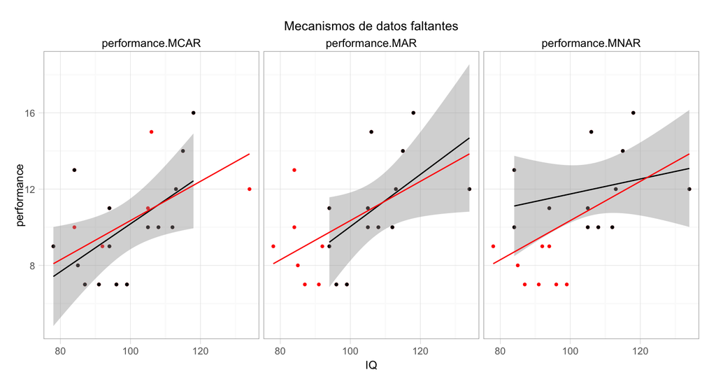

```r
library(plyr)
library(tidyr)
library(dplyr)
library(ggplot2)

datos_cens_l <- datos_cens %>%
  gather(type_miss, value, performance.MCAR:performance.MNAR)

ggplot(datos_cens_l, aes(x = IQ, y = performance)) +
  geom_point(colour = "red", size = 1.5) +
  geom_point(aes(x = IQ, y = value, group = type_miss), size = 1.5) +
  geom_smooth(aes(x = IQ, y = value, group = type_miss), color = "black",
    method = "lm", se = TRUE) +
  geom_smooth(method = "lm", se = FALSE, color = "red") +
  facet_wrap(~ type_miss) +
  labs(title = "Mecanismos de datos faltantes")

datos_cens %>%
  gather(type_miss, value, performance:performance.MNAR) %>%
  group_by(type_miss) %>%
  summarise(
    media = mean(value, na.rm = TRUE),
    se = sd(value, na.rm = TRUE)
    )
```

De las figuras de arriba notemos que en MCAR podemos eliminar datos (aunque no  
sea lo más eficiente) sin producir sesgos en la estimación condicional de *performance* dado *IQ*.

Bajo MAR, eliminar casos faltantes produce sesgos en la estimación de la media y varianza, y posiblemente atenúa la correlación (al eliminar observaciones de una cola).

Finalmente, bajo MNAR, eliminar casos faltantes produce sesgos en estimación de media, varianza y los coeficientes de regresión:

### Métodos usuales de imputación

En un proceso de imputación, buscamos imputar datos faltantes de manera que podamos usar métodos de datos completos. Esta imputación funciona bien cuando no altera de manera considerable las características distribucionales de los datos.

A continuación usamos el ejemplo para mostrar algunos métodos de imputación.

**Media.** Podemos hacer imputación con la media, que en este caso distorsiona la relación entre IQ y performance (*jalándola* hacia cero). También afecta la estimación de la media de performance y deriva en subestimar el error estándar de la variable.

```r
datos_cens$performance_imp_media <- datos_cens$performance.MAR
datos_cens$performance_imp_media[is.na(datos_cens$performance.MAR)] <-
  mean(datos_cens$performance.MAR, na.rm = T)
# Media y desviación estándar
c(mean(datos_cens$performance_imp_media), sd(datos_cens$performance_imp_media))
```

```
## [1] 11.1  2.2
```

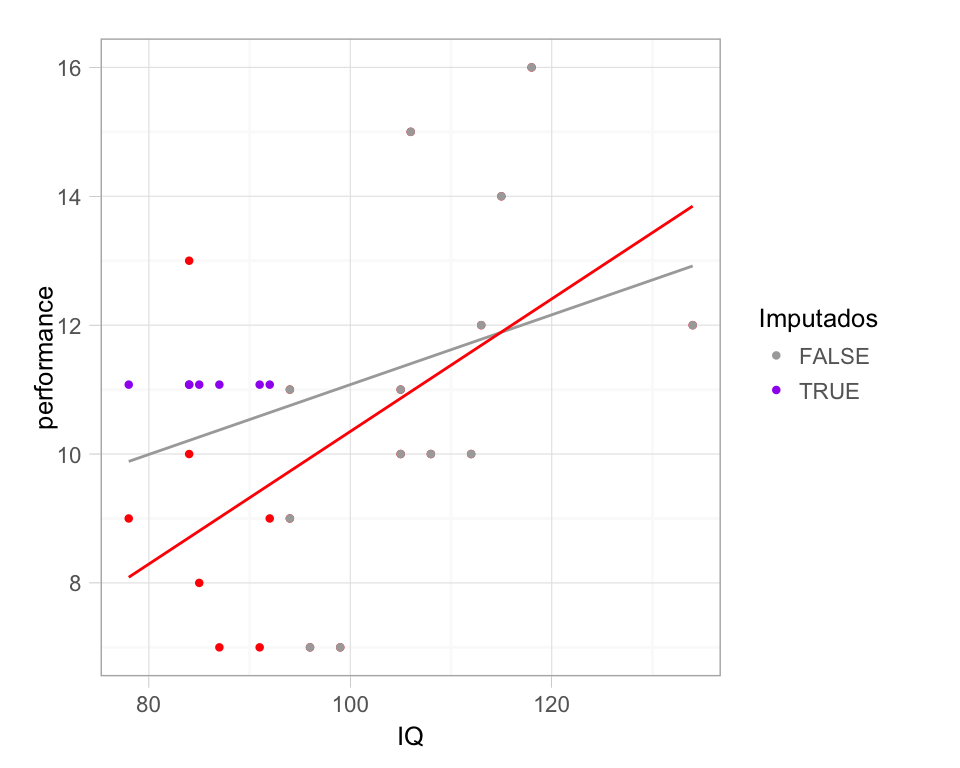

```r
ggplot(datos_cens, aes(x = IQ, y = performance)) +
  geom_point(color = "red", size = 1.5) +
  geom_point(aes(y = performance_imp_media, color = is.na(performance.MAR)),
             size = 1.5) +
  scale_color_manual(name = "Imputados", values = c("darkgray", "purple")) +
  geom_smooth(aes(y = performance_imp_media), method ='lm', se = FALSE,
    color = "darkgray")+
  geom_smooth(aes(y = performance), colour = 'red', se = FALSE, method ='lm')
```

**Regresión.** Otro enfoque es imputación simple con regresión: ajustamos un modelo de performance vs IQ, e imputamos con las predicciones del modelo:

```r
library(arm)
datos_cens$performance_imp_lm <- datos_cens$performance.MAR
mod_1 <- lm(performance.MAR ~ IQ, data = datos_cens)
display(mod_1)
```

```
## lm(formula = performance.MAR ~ IQ, data = datos_cens)
##             coef.est coef.se
## (Intercept) -3.63     6.67
## IQ           0.14     0.06
## ---
## n = 13, k = 2
## residual sd = 2.39, R-Squared = 0.31
```

```r
datos_cens$performance_imp_lm[is.na(datos_cens$performance.MAR)] <-
  predict(mod_1, newdata = subset(datos_cens, is.na(performance.MAR)))

# Media y desviación estándar
c(mean(datos_cens$performance_imp_lm), sd(datos_cens$performance_imp_lm))
```

```
## [1] 10.0  2.7
```

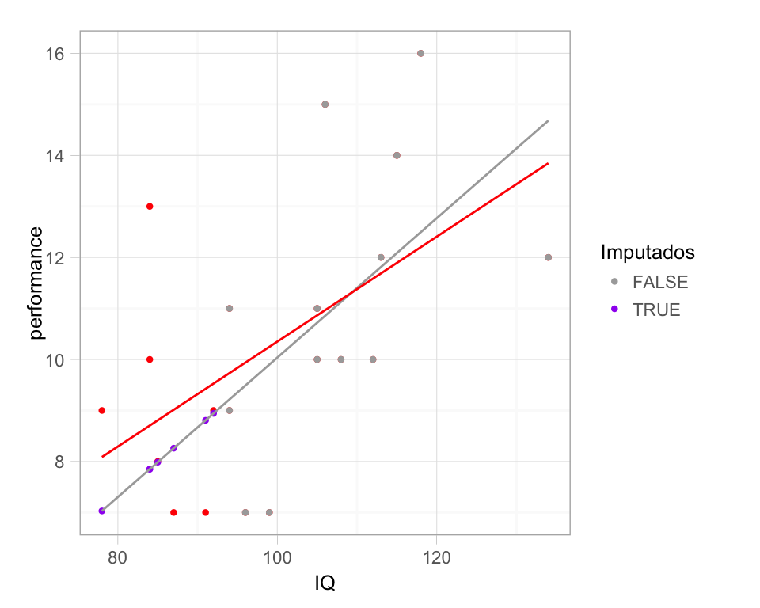

```r
ggplot(datos_cens, aes(x = IQ, y = performance)) +
  geom_point(color = "red", size = 1.5) +
  geom_point(aes(y = performance_imp_lm, color = is.na(performance.MAR)),
             size = 1.5) +
  scale_color_manual(name = "Imputados", values = c("darkgray", "purple")) +
  geom_smooth(aes(y = performance_imp_lm), method ='lm', se = FALSE,
    color = "darkgray")+
  geom_smooth(aes(y = performance), colour = 'red', se = FALSE, method ='lm')
```

**Estocástica con regresión**. Podemos *regresar* la incertidumbre a las imputaciones sumando el error de predicción. La idea es simular observaciones bajo el modelo:

```r
datos_cens$performance_imp_st <- datos_cens$performance.MAR
pred_1 <- predict(mod_1, newdata = subset(datos_cens, is.na(performance.MAR)))
display(mod_1)
```

```
## lm(formula = performance.MAR ~ IQ, data = datos_cens)
##             coef.est coef.se
## (Intercept) -3.63     6.67
## IQ           0.14     0.06
## ---
## n = 13, k = 2
## residual sd = 2.39, R-Squared = 0.31
```

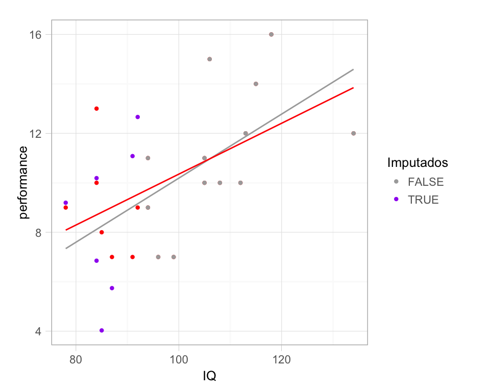

```r
datos_cens$performance_imp_st[is.na(datos_cens$performance.MAR)] <- pred_1 +
  rnorm(sum(is.na(datos_cens$performance.MAR)), 0, sd = 2.39)

ggplot(datos_cens, aes(x = IQ, y = performance)) +
  geom_point(color = "red", size = 1.5) +
  geom_point(aes(y = performance_imp_st, color = is.na(performance.MAR)),
             size = 1.5) +
  scale_color_manual(name = "Imputados", values = c("darkgray", "purple")) +
  geom_smooth(aes(y = performance_imp_st), method ='lm', se = FALSE,
    color = "darkgray")+
  geom_smooth(aes(y = performance), colour = 'red', se = FALSE, method ='lm')
```

Nótese que nuestro proceso produce conjuntos de datos más similares a los datos originales. En el ejemplo siguiente, hacemos cinco imputaciones estocásticas y comparamos con los datos completos:

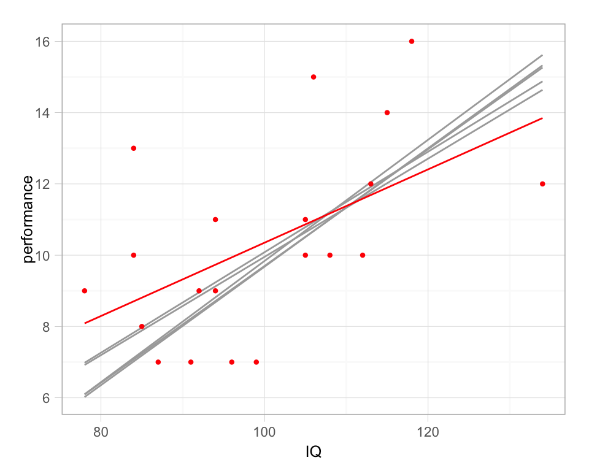

```r
repImp <- function(rep){
  originales <- datos_cens$performance.MAR
  num_faltantes <- sum(is.na(originales))
  faltantes_imp <- pred_1 + rnorm(num_faltantes, 0, sd = 2.39)
  originales[is.na(originales)] <- faltantes_imp
  data.frame(performance = originales, IQ = datos_cens$IQ)
}
imp_rep <- rdply(5, repImp)

orig_1 <- dplyr::select(datos_cens, IQ, performance) %>%
  mutate(.n = 'completos')

ggplot(imp_rep, aes(x = IQ, y = performance, group = .n)) +
  geom_smooth(se=FALSE, method = "lm", color = "darkgray") +
  geom_point(data = orig_1, colour='red', size = 1.5,
    aes(x = IQ, y = performance)) +
  geom_smooth(data = orig_1, colour='red', method = "lm", se = FALSE,
    aes(x = IQ, y = performance))
```

Repite la imputación estocástica para los faltantes MCAR y MNAR.

En la siguiente tabla consideramos un ejercicio de simulación, donde se hicieron distintas imputaciones para cada proceso de censura. En esta tabla vemos que en caso MAR, el único método insesgado es imputación estocástica con regresión. Todos los demás métodos introducen sesgos. Por otra parte, ningún método funciona bien para MNAR.

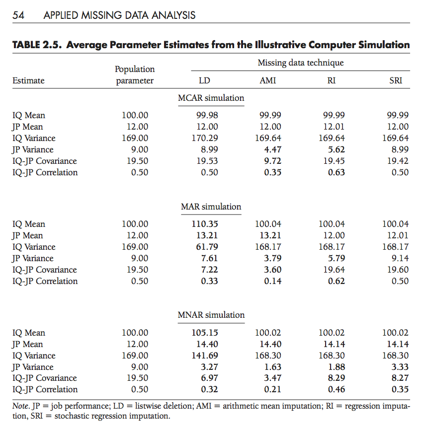

Para imputación bajo MAR, usamos métodos estocásticos basados en modelos para la variable que queremos imputar en términos de otras observadas. Es importante incluir todas las variables que influyen en la censura o no respuesta.

Típicamente hacemos unas pocas replicaciones (por ejemplo 5) de la imputación, y verificamos los resultados de nuestro análisis a lo largo de las 5 imputaciones distintas.

### Verificación de MAR

Como discutimos antes, los faltantes al azar son más fáciles de manejar; sin embargo, en general no podemos estar seguros de que los faltantes dependen de predictores no observados o de las variables mismas en que observamos los faltantes. En general debemos realizar supuestos, o revisar estudios similares. En la práctica se intenta incluir los más predictores posibles de tal manera que que el supuesto de MAR sea razonable. Por ejemplo, puede ser un supuesto muy fuerte decir que la no respuesta a la pregunta de *ingresos* depende únicamente de género, raza y educación, pero es mucho más razonable que suponer que la probabilidad de no respuesta es constante o que depende únicamente de uno de los predictores propuestos.

- No es posible hacer pruebas para confirmar MAR en lugar de MNAR. La razón es precisamente que los datos que necesitamos para ver la posibilidad de MNAR están censurados.
- El enfoque tanto de máxima verosimilitud como de imputación consiste en incluir suficientes variables en el modelo, *todas observadas*, de manera que estas variables expliquen las probabilidades de censura, y así la probabilidad de faltantes no dependa de la variable de interés.
- El caso MNAR es más difícil, pues en este caso típicamente el mecanismo de censura no es ignorable: tenemos que modelarlo. Esto es más complicado técnicamente y generalmente no tenemos información razonable para construir estos modelos.

### Métodos de imputación para varias variables

En esta sección explicaremos la imputación para el caso de faltantes en varias variables y la implementación de imputación del paquete mi, para esto utilizamos el ejemplo del artículo [Multiple Imputation with Diagnostics (mi) in R](http://www.jstatsoft.org/v45/i02/paper) de Yu-sUng Su et al.

- Imputación multivariada. Un método de imputación directo es ajustar un modelo multivariado a todas las variables con datos faltantes. La dificultad de este método es que requiere mucho esfuerzo llegar a un modelo razonable de regresión multivariado, es por ello que en la práctica se suelen usar modelos *estándar* como el normal multivariado o una distribución multinomial para datos discretos. Las calidad de estas imputaciones depende del modelo por lo que se necesitan evaluar el ajuste del mismo; sin embargo, es común que la implementación sea una caja negra.
- Imputación iterativa. Una manera de generalizar los métodos univariados (cuando solo tengo faltantes en una variable) es aplicarlos iterativamente. Si las variables con datos faltantes son una matriz $Y=(Y_1,...,Y_K)$ y las variables completamente observadas son X, comenzamos imputando todos los valores de $Y$ (por ejemplo, seleccionando de los datos observados al azar para cada faltante), y después imputar $Y_1$ dado $Y_2,...,Y_K$ y $X$, imputar $Y_2$ dado $Y_1,Y_3,...,Y_K$ y $X$ donde sustituimos por los valores recien imputados para $Y_1$ y procedemos de esta manera: imputando con procedimientos al azar hasta alcanzar algún criterio de convergencia.

**Ejemplo.** Veamos un ejemplo proveniente de la encuesta de indicadores sociales de Nueva York.

```r
wave3 <- read.table("sis.csv", header = T, sep = ",")

# No lo hagan!
attach(wave3)
n <- nrow(wave3)

 # missing codes:  -9: refused/dk to say if you have this source
 #                 -5: you said you had it but refused/dk the amount

 # Variables:

 # rearn:  respondent's earnings
 # tearn:  spouse's earnings
 # ssi:  ssi for entire family
 # welfare:  public assistance for entire family
 # charity:  income received from charity for entire family
 # sex:  male=1, female=2
 # race of respondent:  1=white, 2=black, 3=hispanic(nonblack), 4=other
 # immig:  0 if respondent is U.S. citizen, 1 if not
 # educ_r:  respondent's education (1=no hs, 2=hs, 3=some coll, 4=college grad)
 # DON'T USE primary:  -9=missing, 0=spouse, 1=respondent is primary earner
 # workmos:  primary earner's months worked last year
 # workhrs:  primary earner's hours/week worked last year

# Creamos algunas variables
white <- ifelse(race == 1, 1, 0)
white[is.na(race)] <- 0
male <- ifelse(sex == 1, 1, 0)
over65 <- ifelse (r_age > 65, 1, 0)
immig[is.na(immig)] <- 0
educ_r[is.na(educ_r)] <- 2.5

# Funciones auxiliares
# Codificar NAs
na.fix <- function(a){
  ifelse (a<0 | a==999999, NA, a)
}

is.any <- function (a) {
  any.a <- ifelse(a>0, 1, 0)
  any.a[is.na(a)] <- 0
  return(any.a)
}

earnings <- na.fix(rearn) + na.fix(tearn)
earnings[workmos==0] <- 0

 # variables resumen para distintos ingresos
any.ssi <- is.any(ssi)
any.welfare <- is.any(welfare)
any.charity <- is.any(charity)

earnings <- earnings/1000

## Imputación aleatoria simple
random.imp <- function (a){
  missing <- is.na(a)
  n.missing <- sum(missing)
  a.obs <- a[!missing]
  imputed <- a
  imputed[missing] <- sample (a.obs, n.missing, replace=TRUE)
  return (imputed)
}

earnings.imp <- random.imp(earnings)

## Zero coding and topcoding
# Topcoding reduce la sensibilidad del los resultados a los valores más altos
# zero coding se utiliza para ajustar el modelo de regresión únicamente a
# aquellas personas con ingreso positivo

topcode <- function (a, top){
  return (ifelse (a>top, top, a))
}

earnings.top <- topcode(earnings, 100)
workhrs.top <- topcode(workhrs, 40)

## Descrpción

 # interest:  interest of entire family
interest <- na.fix(interest)

 # transforming the different sources of income
interest <- interest/1000

## Simple random imputation
interest.imp <- random.imp (interest)

## Imputación iterativa
datos <- data.frame(earnings, interest.imp, male, over65, white, immig,
    educ_r, workmos, workhrs.top, any.ssi, any.welfare, any.charity)
str(datos)

impute <- function(a, a.impute){
   ifelse(is.na(a), a.impute, a)
}

# número de iteraciones
n.sims <- 10
# Y: earnings, interest
for (s in 1:n.sims){
  lm.1 <- lm (earnings ~ interest.imp + male + over65 + white + immig +
    educ_r + workmos + workhrs.top + any.ssi + any.welfare + any.charity)
  pred.1 <- rnorm(n, predict(lm.1), sigma.hat(lm.1))
  earnings.imp <- impute (earnings, pred.1)

  lm.2 <- lm (interest ~ earnings.imp + male + over65 + white + immig +
    educ_r + workmos + workhrs.top + any.ssi + any.welfare + any.charity)
  pred.2 <- rnorm(n, predict(lm.2), sigma.hat(lm.2))
  interest.imp <- impute(interest, pred.2)
}
```

Ahora veamos como realizar una imputación usando el paquete *mi*. Este paquete describe la imputación de datos como un proceso que consta de 4 pasos.

1. Preparación
- Visualización de patrones de datos faltantes.
- Identificación de problemas estructurales en los datos y preprocesamiento de los mismos.
2. Imputación
- Imputación iterativa con base al modelo condicional.
- Revisón del ajuste de los modelos condicionales con el fin de observar si los valores imputados son razonables.
- Revisión de convergencia del procedimiento.
3. Análisis
- Obtención de datos completos.
- Combinación (*pooling*) del análisis de datos completos en múltiples conjuntos de datos imputados.
4. Validación
- Análisis de sensibilidad.
- Validación cruzada.
- Revisión de compatibilidad

### Ejemplo: Community Health Advisory and Information Network (CHAIN)

En este ejemplo utilizaremos un subconjunto de las variables del proyecto [CHAIN](http://www.nyhiv.org/data_chain.html), este es un estudio longitudinal de personas que viven VIH en la ciudad de Nueva York.

#### 1. Preparación

Comencemos con la visualización de patrones en los datos faltantes. Los patrones de datos faltantes se refieren a la configuración de datos observados y faltantes de una base de datos. La gráfica del lado izquierdo muestra la matriz con los datos observados en azúl y los faltantes en rojo. Esta gráfica puede ser difícil de interpretar, es por ello que en la figura del lado derecho ordenamos y creamos conglomerados con los datos.

```r
library(mi)
data(CHAIN)
str(CHAIN)
```

```
## 'data.frame':    532 obs. of  7 variables:
##  $ h39b.W1       : num  10 0 NA NA 7.09 ...
##  $ age.W1        : num  29 38 47 53 42 49 39 42 63 34 ...
##  $ c28.W1        : num  5 5 6 2 2 4 4 1 2 6 ...
##  $ pcs.W1        : num  34.2 58.1 21.9 18.7 54.1 ...
##  $ mcs37.W1      : num  1 0 0 0 0 0 1 1 0 0 ...
##  $ b05.W1        : num  4 5 1 5 4 4 1 NA NA 5 ...
##  $ haartadhere.W1: num  1 2 1 0 1 2 1 0 2 2 ...
```

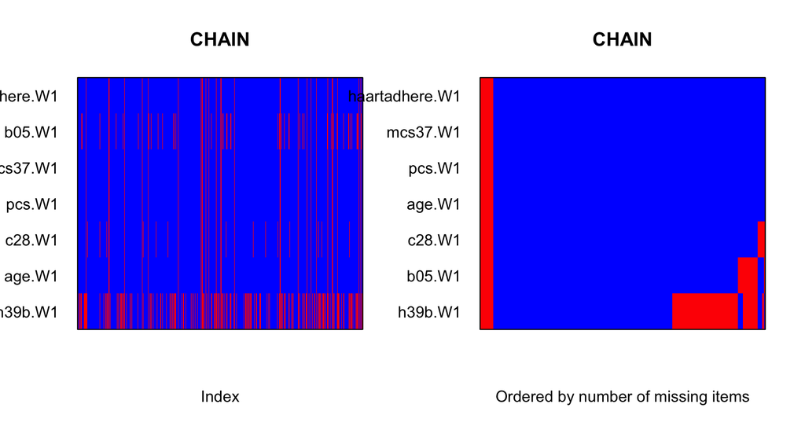

```r
par(mfrow = c(1,2))
mp.plot(CHAIN, clustered = FALSE)
mp.plot(CHAIN, x.order = TRUE, y.order = TRUE, clustered = TRUE)
```

La instrucción *mi.info* produce una matriz de información que especifica el modelo de imputación.

```r
info <- mi.info(CHAIN)
info
```

```
##            names include order number.mis all.mis                type
## 1        h39b.W1     Yes     1        179      No         nonnegative
## 2         age.W1     Yes     2         24      No positive-continuous
## 3         c28.W1     Yes     3         38      No positive-continuous
## 4         pcs.W1     Yes     4         24      No positive-continuous
## 5       mcs37.W1     Yes     5         24      No              binary
## 6         b05.W1     Yes     6         63      No ordered-categorical
## 7 haartadhere.W1     Yes     7         24      No ordered-categorical
##   collinear
## 1        No
## 2        No
## 3        No
## 4        No
## 5        No
## 6        No
## 7        No
```

También podemos realizar cambios en *mi.info* usando la función *update*. Por ejemplo, si no queremos incluir *mcs37.W1* en el proceso de imputación haríamos:

```r
info <- update(info, "include", list("mcs37.W1" = FALSE))
info
```

```
##            names include order number.mis all.mis                type
## 1        h39b.W1     Yes     1        179      No         nonnegative
## 2         age.W1     Yes     2         24      No positive-continuous
## 3         c28.W1     Yes     3         38      No positive-continuous
## 4         pcs.W1     Yes     4         24      No positive-continuous
## 5       mcs37.W1      No    NA         24      No              binary
## 6         b05.W1     Yes     5         63      No ordered-categorical
## 7 haartadhere.W1     Yes     6         24      No ordered-categorical
##   collinear
## 1        No
## 2        No
## 3        No
## 4        No
## 5        No
## 6        No
## 7        No
```

```r
# la regresamos ya que en este ejercicio si queremos imputarla
info <- update(info, "include", list("mcs37.W1" = TRUE))
```

También usamos *mi.info* para identificar de problemas estructurales.

```r
CHAIN_2 <- mi.preprocess(CHAIN)
attr(CHAIN_2, "mi.info")
```

```
##            names include order number.mis all.mis                type
## 1 h39b.W1.mi.log     Yes     1        367      No      log-continuous
## 2  age.W1.mi.log     Yes     2         24      No      log-continuous
## 3  c28.W1.mi.log     Yes     3         38      No      log-continuous
## 4  pcs.W1.mi.log     Yes     4         24      No      log-continuous
## 5       mcs37.W1     Yes     5         24      No              binary
## 6         b05.W1     Yes     6         63      No ordered-categorical
## 7 haartadhere.W1     Yes     7         24      No ordered-categorical
## 8 h39b.W1.mi.ind     Yes     8        179      No              binary
##   collinear
## 1        No
## 2        No
## 3        No
## 4        No
## 5        No
## 6        No
## 7        No
## 8        No
```

La nueva matriz de información indica que las variables h39b.W1, age.W1, c28.W1 y pcs.W1 se han transformado. La transformación se debe a que los datos semi-continuos (continus positivos, no negativos y proporciones) tienen cotas o truncaciones y no son de distribuciones estándar.

Al cambiar el tipo de cada variable, *mi* elige un modelo condicional distinto para ajustar a las variables alteradas. Aquí también podemos cambiar los default, por ejemplo cambiar el tipo de *h39b.W1* de no negativo a continuo.

```r
info <- update(info, "type", list("h39b.W1" = "continuous"))
info
```

```
##            names include order number.mis all.mis                type
## 1        h39b.W1     Yes     1        179      No          continuous
## 2         age.W1     Yes     2         24      No positive-continuous
## 3         c28.W1     Yes     3         38      No positive-continuous
## 4         pcs.W1     Yes     4         24      No positive-continuous
## 5       mcs37.W1     Yes     5         24      No              binary
## 6         b05.W1     Yes     6         63      No ordered-categorical
## 7 haartadhere.W1     Yes     7         24      No ordered-categorical
##   collinear
## 1        No
## 2        No
## 3        No
## 4        No
## 5        No
## 6        No
## 7        No
```

Y los modelos quedan como sigue.

```r
info$imp.formula
```

```
##                                                                   h39b.W1
##            "h39b.W1 ~ age.W1 + c28.W1 + pcs.W1 + b05.W1 + haartadhere.W1"
##                                                                    age.W1
##            "age.W1 ~ h39b.W1 + c28.W1 + pcs.W1 + b05.W1 + haartadhere.W1"
##                                                                    c28.W1
##            "c28.W1 ~ h39b.W1 + age.W1 + pcs.W1 + b05.W1 + haartadhere.W1"
##                                                                    pcs.W1
##            "pcs.W1 ~ h39b.W1 + age.W1 + c28.W1 + b05.W1 + haartadhere.W1"
##                                                                  mcs37.W1
## "mcs37.W1 ~ h39b.W1 + age.W1 + c28.W1 + pcs.W1 + b05.W1 + haartadhere.W1"
##                                                                    b05.W1
##            "b05.W1 ~ h39b.W1 + age.W1 + c28.W1 + pcs.W1 + haartadhere.W1"
##                                                            haartadhere.W1
##            "haartadhere.W1 ~ h39b.W1 + age.W1 + c28.W1 + pcs.W1 + b05.W1"
```

Notamos que se asume linearidad entre las variables dependientes y los predictores. Sin embargo, podemos cambiar las fórmulas añadiendo interacciones y términos cuadráticos.

```r
info.upd <- update(info, "imp.formula",
  list("h39b.W1" = "h39b.W1 ~ age.W1^2 + c28.W1*pcs.W1 + mcs37.W1 + b05.W1 +
       haartadhere.W1"))
info.upd$imp.formula["h39b.W1"]
```

```
##                                                                       h39b.W1
## "h39b.W1 ~ age.W1^2 + c28.W1*pcs.W1 + mcs37.W1 + b05.W1       haartadhere.W1"
```

#### 2. Imputación

Una vez que preparamos todo, la imputación es sencilla; sin embargo, se debe verificar el ajuste de los modelos y la convergencia.

```r
CHAIN_new <- mi.preprocess(CHAIN)
IMP <- mi(CHAIN_new, n.iter = 50)
```

[output not shown]

[output cut: 230 more lines]

[output not shown]

Si el ajuste de los modelos de imputación es malo es poco probable que imputemos valores razonables. Podemos revisar el ajuste usando las siguientes gráficas. La primera gráfica muestra histogramas de los observados (azúl) e imputados (rojo). El segundo es *binned residuals* que grafica el promedio de los residuales en bins contra los valores esperados. El tercero es un diagrama de dispersión que grafica los valores observados contra los valores de predicción, además se agrega una curva loess.

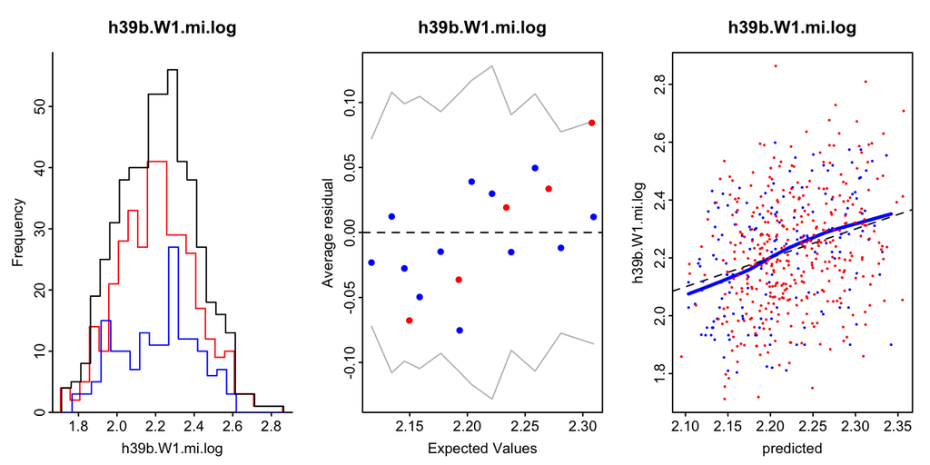

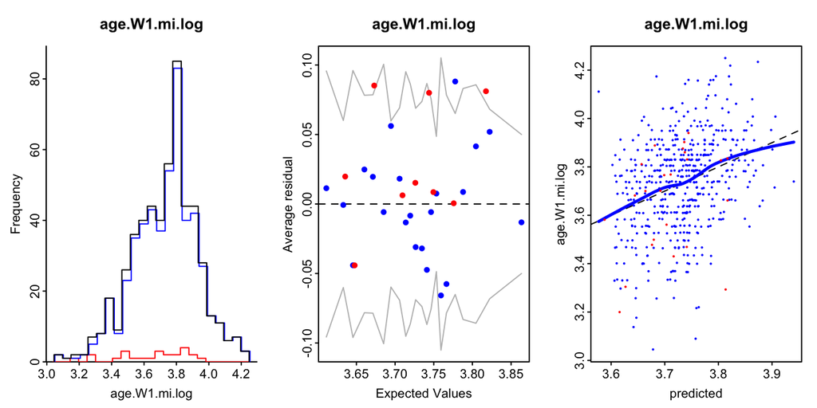

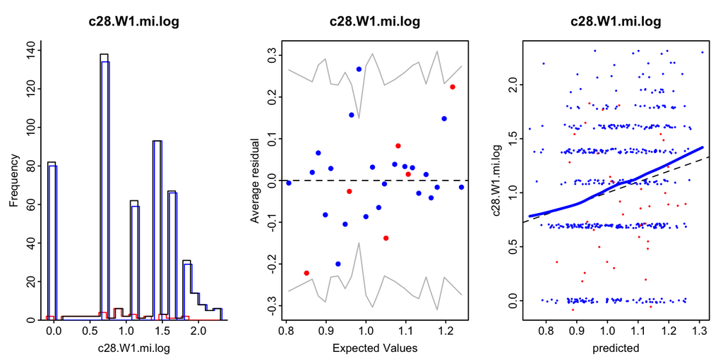

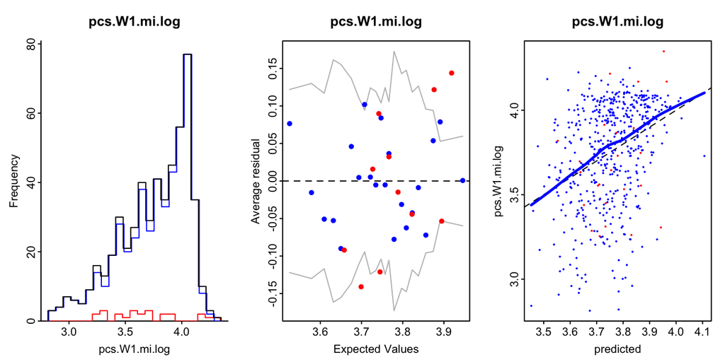

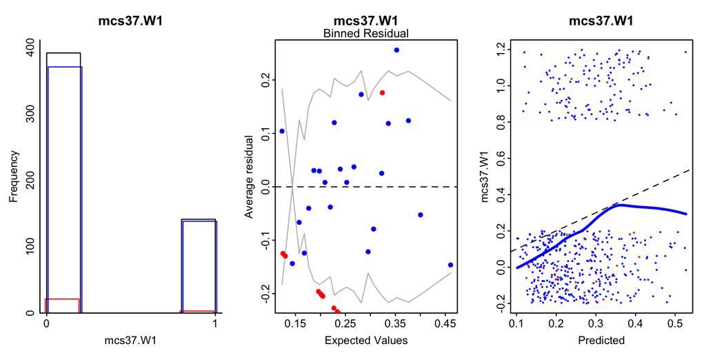

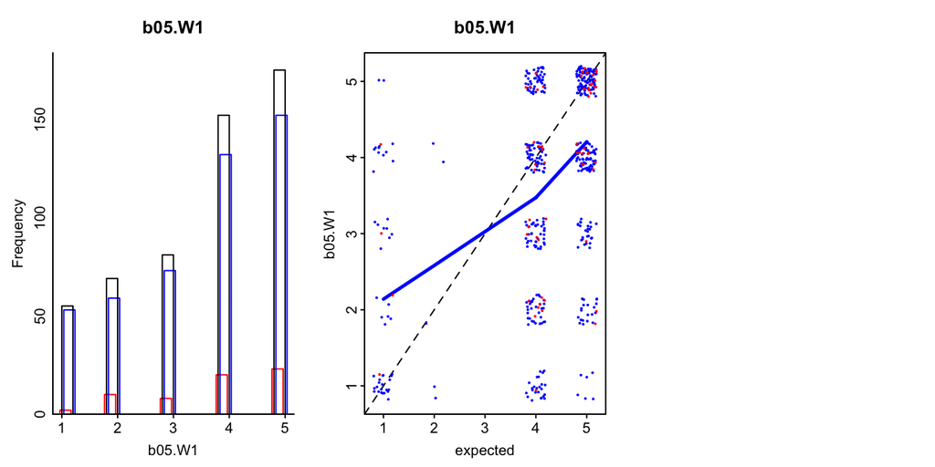

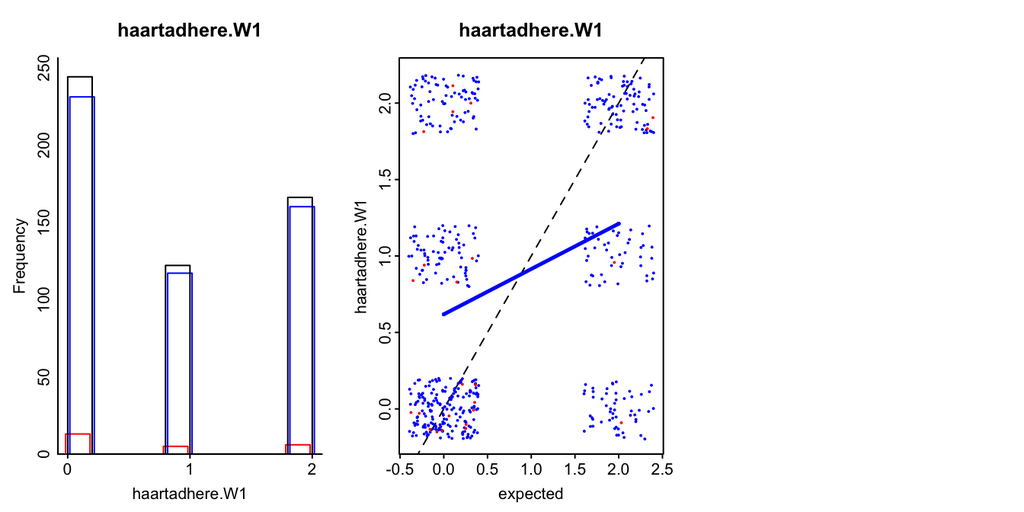

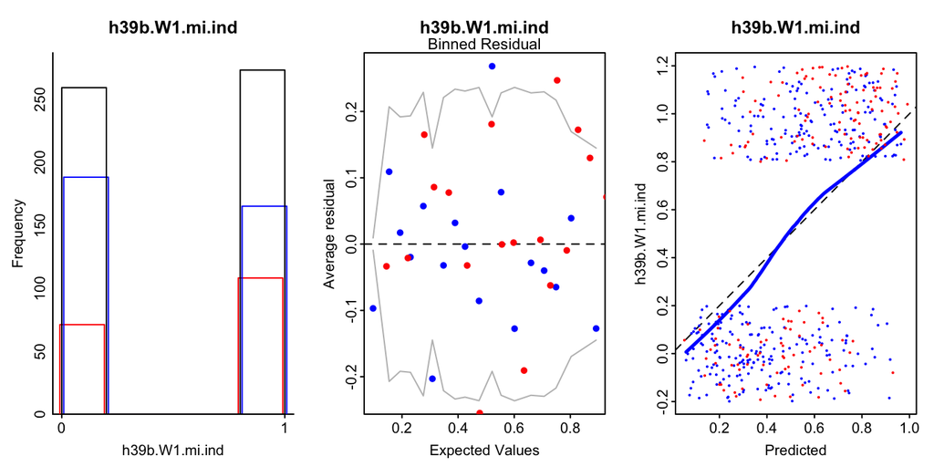

```r
plot(IMP)
```

Las gráficas también nos pueden ayudar a detectar si no se cumple el supuesto MAR, pues podemos comparar los valores observados y los valores imputados.

En cuanto a convergencia mi calcula la media y desviación estándar de cada variable en distintas cadenas (n.imp). Considera que la imputación ha convergido si $\hat{R} < 1.1$ para todos los parámetros.

```r
bugs.mi(IMP)
```

```
##
##  3 chains, each with 20 iterations (first 0 discarded)
##  n.sims = 60 iterations saved
##                      mean sd 2.5% 25% 50% 75% 97.5% Rhat n.eff
## mean(h39b.W1.mi.log)  2.2  0  2.1 2.2 2.2 2.2   2.2  2.4     4
## mean(age.W1.mi.log)   3.7  0  3.7 3.7 3.7 3.7   3.7  1.0    60
## mean(c28.W1.mi.log)   1.0  0  1.0 1.0 1.0 1.0   1.1  1.0    58
## mean(pcs.W1.mi.log)   3.8  0  3.7 3.7 3.8 3.8   3.8  1.0    60
## mean(mcs37.W1)        0.3  0  0.3 0.3 0.3 0.3   0.3  1.0    60
## mean(b05.W1)          3.6  0  3.6 3.6 3.6 3.6   3.6  1.2    15
## mean(haartadhere.W1)  1.9  0  1.8 1.9 1.9 1.9   1.9  1.0    60
## mean(h39b.W1.mi.ind)  0.5  0  0.5 0.5 0.5 0.5   0.5  1.2    14
## sd(h39b.W1.mi.log)    0.2  0  0.2 0.2 0.2 0.2   0.2  1.3    12
## sd(age.W1.mi.log)     0.2  0  0.2 0.2 0.2 0.2   0.2  1.0    58
## sd(c28.W1.mi.log)     0.6  0  0.6 0.6 0.6 0.6   0.6  1.0    60
## sd(pcs.W1.mi.log)     0.3  0  0.3 0.3 0.3 0.3   0.3  1.0    60
## sd(mcs37.W1)          0.4  0  0.4 0.4 0.4 0.4   0.4  1.0    60
## sd(b05.W1)            1.3  0  1.3 1.3 1.3 1.4   1.4  1.0    49
## sd(haartadhere.W1)    0.9  0  0.9 0.9 0.9 0.9   0.9  1.1    26
## sd(h39b.W1.mi.ind)    0.5  0  0.5 0.5 0.5 0.5   0.5  1.2    21
##
## For each parameter, n.eff is a crude measure of effective sample size,
## and Rhat is the potential scale reduction factor (at convergence, Rhat=1).
```

Si no se ha logrado convergencia podemos continuar las iteraciones sobre el objeto mi anterior:

```r
IMP <- mi(IMP, run.past.convergence = TRUE, n.iter = 10)
```

[output not shown]

#### 3. Combinación de inferencias (Rubin 1987)

En el proceso anterior realizamos 3 cadenas de imputaciones, esto es, tenemos 3 bases de datos con datos imputados. Podemos extraer las bases de datos con los datos imputados para hacer análisis.

```r
IMP.dat.all <- mi.completed(IMP)
```

O podemos extraer únicamente uno.

```r
IMP.dat <- mi.data.frame(IMP, m = 1)
```

Al hacer análisis, en lugar de reemplazar cada valor faltante con un valor imputado de manera aleatoria, tiene sentido reemplazar cada valor faltante con varios valores imputados que reflejen nuestra incertidumbre acerca del modelo de imputación. Por ejemplo, si imputamos usando un modelo de regresión queremos reflejar no solamente la variación muestral (propia de imputación aleatoria), sino también la incertidumbre de los coeficientes de regresión del modelo. Si modelamos los coeficientes mismos, podemos obtener un nuevo conjunto de imputaciones para cada conjunto simulado de la distribución de coeficientes.

Esta es la idea detrás de imputación multiple, se generean varios valores imputados para cada valor faltante, cada uno es la predicción de un modelo ligeramente diferente y que además refleja variabilidad muestral. ¿Cómo analizamos estos datos? La idea es usar cada conjunto de datos imputados (junto con los observados) para crear conjuntos de datos *completos*. Dentro de cada conjunto de datos completos podemos llevar a cabo un análisis estándar.

Por ejemplo, supongamos que queremos hacer inferencia acerca de un coeficiente de regresión $\beta$, obtenemos estimaciones $\hat{\beta}_m$ usando cada uno de los M conjuntos de datos, y obtenemos también errores estándar $s_1,...,s_M$. Para obtener una estimación puntual usamos la media de las $M$ estimaciones: $\hat{\beta}=\frac{1}{M}\sum_{m}\hat{\beta}_m$

En cuanto al error estándar, no es tan sencillo como la media. Recordemos que los errores estándar provenientes de imputaciones múltiples tienen dos fuentes de variación: el error estándar que hubiese resultado si los datos fueran completos y el error muestral adicional proveniente de los datos faltantes. Es así que las fórmulas de varianza consisten de un término correspondiente a variación dentro (*Within*) y otro entre (*Between*):

$V_{\beta} = W + (1+\frac{1}{M})B$

La varianza dentro es el promedio de las varianzas:

$W=\frac{1}{M}\sum_{m}s_m^2$

y estima la variabilidad que hubiera resultado si no hubiera datos faltantes. Por otra parte, como hemos discutido, los valores faltantes deben aumentar los errores estándar, es así que surge el término de varianza *Between*.

$B=\frac{1}{M-1}\sum_{m}(\hat{\beta}_m-\hat{\beta})^2$

que representa la variación adicional debida a las fluctuaciones entre $\hat{\beta}_m$ provenientes de los diferentes valores imputados.

Para hacer este proceso en mi haríamos:

```r
fit <- lm.mi(h39b.W1 ~ age.W1 + c28.W1 + pcs.W1 + mcs37.W1 + b05.W1 +
               haartadhere.W1, IMP)
display(fit)
```

```
## =======================================
## Separate Estimates for each Imputation
## =======================================
##
## ** Chain 1 **
## lm(formula = formula, data = mi.data[[i]])
##                coef.est coef.se
## (Intercept)    14.44     1.45
## age.W1         -0.08     0.02
## c28.W1         -0.29     0.10
## pcs.W1         -0.03     0.02
## mcs37.W1        0.73     0.43
## b05.W1         -1.08     0.14
## haartadhere.W1 -1.01     0.22
## ---
## n = 532, k = 7
## residual sd = 4.34, R-Squared = 0.19
##
## ** Chain 2 **
## lm(formula = formula, data = mi.data[[i]])
##                coef.est coef.se
## (Intercept)    16.56     1.42
## age.W1         -0.11     0.02
## c28.W1         -0.36     0.10
## pcs.W1         -0.02     0.02
## mcs37.W1        0.93     0.42
## b05.W1         -1.15     0.14
## haartadhere.W1 -1.34     0.21
## ---
## n = 532, k = 7
## residual sd = 4.20, R-Squared = 0.26
##
## ** Chain 3 **
## lm(formula = formula, data = mi.data[[i]])
##                coef.est coef.se
## (Intercept)    15.78     1.45
## age.W1         -0.09     0.02
## c28.W1         -0.41     0.09
## pcs.W1         -0.04     0.02
## mcs37.W1        0.95     0.44
## b05.W1         -0.96     0.15
## haartadhere.W1 -1.08     0.22
## ---
## n = 532, k = 7
## residual sd = 4.35, R-Squared = 0.21
##
## =======================================
## Pooled Estimates
## =======================================
## lm.mi(formula = h39b.W1 ~ age.W1 + c28.W1 + pcs.W1 + mcs37.W1 +
##     b05.W1 + haartadhere.W1, mi.object = IMP)
##                coef.est coef.se
## (Intercept)    15.59     1.90
## age.W1         -0.09     0.03
## c28.W1         -0.36     0.12
## pcs.W1         -0.03     0.02
## mcs37.W1        0.87     0.45
## b05.W1         -1.06     0.18
## haartadhere.W1 -1.14     0.30
## ---
```

### 4. Validación

- Análisis de sensibilidad: Podemos evaluar la sensibilidad de los resultados de los análisis agregados ante cambios en la especificación de los modelos dentro del conjunto de modelos posibles de acuerdo a la evaluación gráfica.
- Validación cruzada. Podemos evaluar el supuesto MAR, creando datos faltantes de los datos imputados usando los mecansimos de faltantes que suponemos. Reimputamos y comparamos.

### Otros aspectos a tomar en cuenta

Imputación de datos colineales. El paquete *mi* tiene estrategias para dos casos: correlación perfecta y restricciones aditivas.

- Correlación perfecta. En muchos datos una variable aparece más de una vez, en distintas escalas. Por ejemplo, podríamos tener PIB per cápita en pesos y en miles de pesos. En este caso, si el patrón de faltantes es el mismo en ambas variables, *mi()* incluirá sólo una de las variables duplicadas como parte del proceso iterativo y después copiará los valores a la variable no imputada.
- Restricciones aditivas.

### Recursos adicionales

- [Statistical Analysis with Missing Data](http://www.amazon.com/Statistical-Analysis-Missing-Roderick-Little/dp/0471183865) Little, Rubin.
- [Data Analysis Using Regression and Multilevel/Hierarchical Models](http://www.cambridge.org/am/academic/subjects/statistics-probability/statistical-theory-and-methods/data-analysis-using-regression-and-multilevelhierarchical-models) cap. 25, Gelman, Hill.
- [A multivariate technique for multiply imputing missing values using a sequence of regression models](http://www5.statcan.gc.ca/olc-cel/olc.action?ObjId=12-001-X20010015857&ObjType=47&lang=en) Van Hoewyk, Lepkowski, Solenberger y Raghunathan.
- [Applied Missing Data Analysis](http://www.appliedmissingdata.com), Enders.
- [The multiple imputation FAQ page](http://sites.stat.psu.edu/~jls/mifaq.html)